# Untitled

Zachary Atter

19/02/2022

##Setting up enviroment

```r
load("NHANES0506.rda")
library(tidyverse)
```

```r
# library(Hmisc)
# library(summarytools)
# library(haven)
library(labelled)
library(cowplot)
library(kableExtra)
library(broom)
```

```r
#summary(dat)

#Annual family income
print("Annual family income largest values")
```

```
## [1] "Annual family income largest values"
```

```r
tail(sort(dat$INDFMINC),n=15)
```

```
##  [1] 13 13 13 77 77 77 77 99 99 99 99 99 99 99 99
```

```r
#Jumps from 13 to 77, should investigate this
#Body Mass Index
print("BMI largest values")
```

```
## [1] "BMI largest values"
```

```r
tail(sort(dat$BMXBMI),n=5)
```

```
## [1]  56.40  58.14  58.33  58.95 130.21
```

```r
#130.21 extremely high compared to others, norm max value around 60.
```

We looked at the summary of the data to see if there are any outliers, missing data. We found that the highest amount of missing data was around 9% thus missingness was not a problem so we kept all variables. We identified LBXGH as the response variable as it is the % of Glycohemoglobin thus we remove all subjects that have a missing value for this variable as will not be useful in model prediction

In terms of outliers we identified a very large BMI value of 130.21, calculating their weight using their height (168.8cm) we found they would have a weight of 371kg, thus we conclude this value is an error and will remove it. The family income variable has several values of 77 and 99 while the rest are below 14 thus we conclude that 77 and 99 are codes representing missing value or refused to comment, thus we remove these values.

```r
#cleaning data to remove extreme values and create factors and creating new diabetes variable
data_cleaned<-dat%>%filter(BMXBMI<130,INDFMINC<14,!is.na(LBXGH))%>%
  mutate(Gender=factor(RIAGENDR,levels=c(1,2),labels=c("Male","Female")),
                  Ethnicity=factor(RIDRETH1,levels=c(1,2,3,4,5),labels=c("Mexican American","Other Hispanic","Non-Hispanic White","Non-Hispanic Black","Other Race")),
                  Education=factor(DMDEDUC2,levels = c(1,2,3,4,5),labels=c("< 9th grade","9-11th grade","high school grade","Some College","College graduate")),
                  Married=factor(DMDMARTL,levels = c(1:6),labels=c("Married","Widowed","Divorced","Seperated","Never Married","Living with partner")))%>%
  select(-RIAGENDR,-RIDRETH1,-DMDEDUC2,-DMDMARTL)%>%
  mutate(diabetes=ifelse(LBXGH>=6.5,"diabetes",ifelse(LBXGH>5.7,"pre-diabetes",ifelse(is.na(LBXGH)==F,"no diabetes",NA))))

no_diabetes<-data_cleaned%>%filter(diabetes=="no diabetes")

#investigating missing data (by calculating percentage of missing data for each variable)
missing_data_perc<-no_diabetes %>% summarize_all(funs(round(sum(is.na(.))*100 / length(.),3)))
dat %>% summarize_all(funs(round(sum(is.na(.))*100 / length(.),3)))
```

```
##   SEQN RIAGENDR RIDAGEYR RIDRETH1 DMDEDUC2 DMDMARTL INDFMINC LBXGH BMXHT BMXBMI
## 1    0        0        0        0        0        0    0.896 4.876 0.199  0.299
##   BMXWAIST LBXTR LBDLDL LBXAPB valid_days valid_min cpm sed_min light_min
## 1    2.587 5.672  8.557  5.373          0         0   0       0         0
##   life_min mod_min vig_min lightlife_min mvpa_min active_min sed_percent
## 1        0       0       0             0        0          0           0
##   light_percent life_percent mod_percent vig_percent lightlife_percent
## 1             0            0           0           0                 0
##   mvpa_percent active_percent sed_bouted_30min num_mvpa_bouts num_vig_bouts
## 1            0              0                0              0             0
##   mvpa_bouted vig_bouted guideline_min
## 1           0          0             0
```

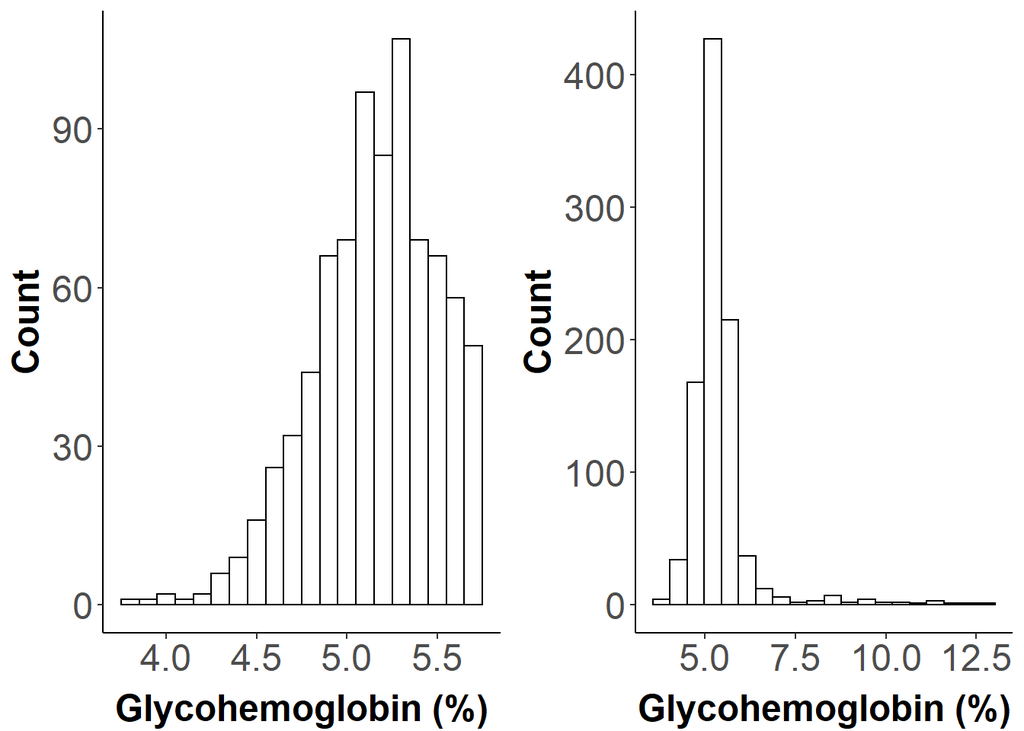

```r
#denisty/histogram of response variable to see skewness of response


hist_no_dia<-ggplot(no_diabetes,aes(x=LBXGH))+geom_histogram(bins = 20,color="black",fill="white")+
  ylab("Count")+
  xlab("Glycohemoglobin (%)")+
  theme(plot.background = element_rect(fill = "white"),panel.background = element_rect(fill = "white"),axis.line.x = element_line(color = "black"), axis.line.y = element_line(color = "black"),legend.background = element_rect(colour = "grey50"),panel.border = element_blank(),panel.grid.major = element_blank(), panel.grid.minor = element_blank(),axis.title=element_text(size=18,face="bold"),axis.text=element_text(size=18),axis.title.x = element_text(vjust=-0.1),legend.title=element_blank())

hist_dia<-ggplot(data_cleaned,aes(x=LBXGH))+geom_histogram(bins = 20,color="black",fill="white")+
  ylab("Count")+
  xlab("Glycohemoglobin (%)")+
  theme(plot.background = element_rect(fill = "white"),panel.background = element_rect(fill = "white"),axis.line.x = element_line(color = "black"), axis.line.y = element_line(color = "black"),legend.background = element_rect(colour = "grey50"),panel.border = element_blank(),panel.grid.major = element_blank(), panel.grid.minor = element_blank(),axis.title=element_text(size=18,face="bold"),axis.text=element_text(size=18),axis.title.x = element_text(vjust=-0.1),legend.title=element_blank())

plot_grid(hist_no_dia,hist_dia)
```

We now create some plots from the filtered data that only includes subjects that have not been identified as diabetic/pre-diabetic from their Glycohemoglobin (A1C) levels.

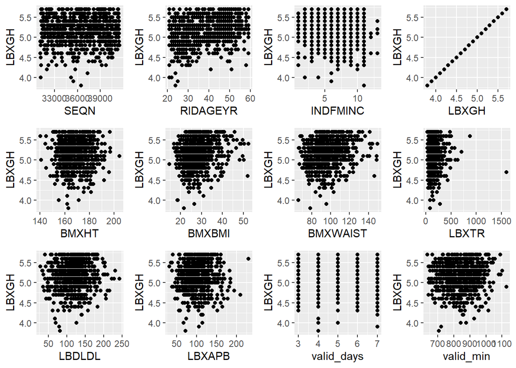

```r
#splitting continous variables so easier to view (gave up on automating the process)
contvar<-set_names(names(no_diabetes%>%
                select_if(is.numeric)))
catvar<-set_names(names(no_diabetes%>%
                select_if(is.factor)))

scatter_fun<-function(x){
 ggplot(no_diabetes,aes(x=.data[[x]],y=.data[["LBXGH"]]))+geom_point()
}

split_var<-split(contvar,ceiling(seq_along(contvar)/12))

scatter1<-map(as.list(names(split_var[[1]])),~scatter_fun(.x))
scatter2<-map(as.list(names(split_var[[2]])),~scatter_fun(.x))
scatter3<-map(as.list(names(split_var[[3]])),~scatter_fun(.x))

plot_grid(plotlist = scatter1)
```

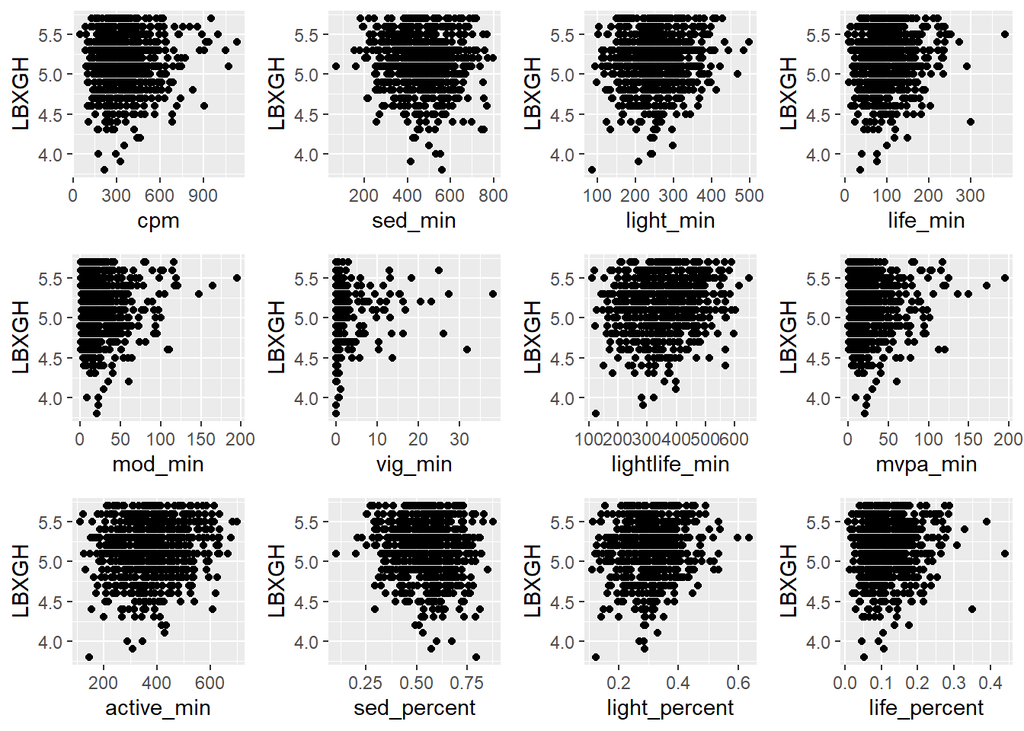

```r
plot_grid(plotlist = scatter2)
```

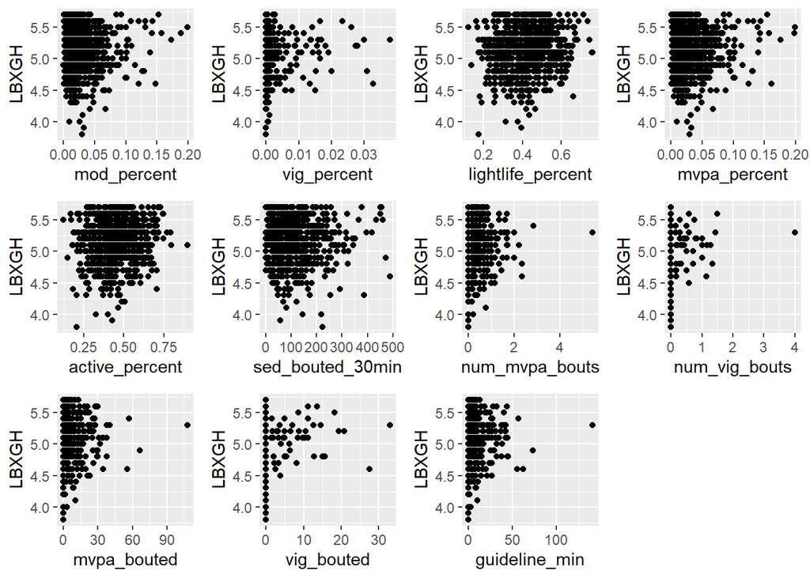

```r
plot_grid(plotlist = scatter3)
```

Next we plot each continous variable against the A1C value to identify any that are associated with it. From the plots we can see BMI waist circumference, the physical activity related variables, etc….

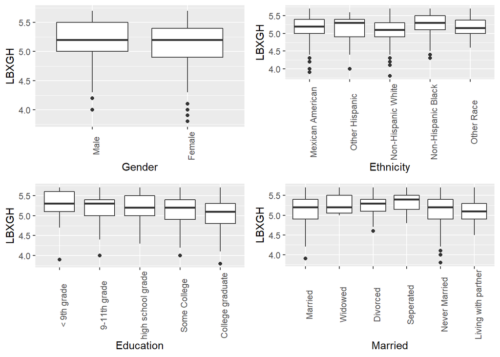

```r
box_fun<-function(x){
 ggplot(no_diabetes,aes(x=.data[[x]],y=.data[["LBXGH"]]))+geom_boxplot()+theme(axis.text.x = element_text(angle = 90))
}
eval_plots<-map(catvar,~box_fun(.x))
plot_grid(plotlist = eval_plots)
```

Producing boxplots for factor variables we see a slight variation but nothing that looks significant.

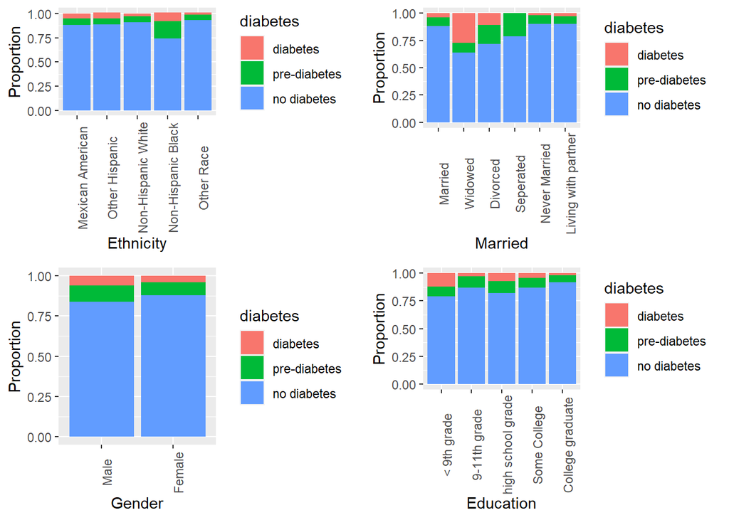

```r
diabetes<-data_cleaned%>%filter(diabetes %in% c("diabetes","pre-diabetes"))

prop_func<-function(x_var){
  #creating proportion dataset to feed into ggplot
  group_var<-enquo(x_var)
  merge_dat<-data_cleaned%>%group_by(!!group_var)%>%summarise(count_var=n())
  plot_data<-data_cleaned%>%group_by(!!group_var,diabetes)%>%
     summarise(count_diabetes=n())%>%
     left_join(merge_dat)%>%
     mutate(proportion=round(count_diabetes/count_var,2))

#reordering diabetes levels for the plot
plot_data$diabetes <- factor(plot_data$diabetes, levels = c(NA, "diabetes", "pre-diabetes","no diabetes"))

#plotting data
ggplot(plot_data,aes(x=!!group_var,y=proportion,fill=diabetes))+
  geom_bar(stat="identity")+
  ylab("Proportion")+
  theme(axis.text.x = element_text(angle = 90))
}

#Running function on the categorical variables and putting into 2 by 2 plot to view all at once
pf_eth<-prop_func(Ethnicity)
pf_m<-prop_func(Married)
pf_g<-prop_func(Gender)
pf_ed<-prop_func(Education)
plot_grid(pf_eth,pf_m,pf_g,pf_ed)
```

To give a better understanding of the categorical variables we plotted the proportion of each level of each categorical variable that had each diabetic status. From the plot we can see that non-hispanic black ethnicity, widowed, divorced and <9th grade education all have a high proportion of diabtic and pre-diabetic individuals which we will keep in mind for model selection.

```r
#removing SEQN variable as is only id number
nd_filtered<-no_diabetes%>%select(-SEQN)

#using only complete observations (this will introduce bias but will allow us to see associations that should exist even with the missing data unless systematic will need to look at how data was gathered etc)
correlation<-round(cor(select_if(nd_filtered,is.numeric),use = "complete.obs"),2)
correlation
```

```
##                   RIDAGEYR INDFMINC LBXGH BMXHT BMXBMI BMXWAIST LBXTR LBDLDL
## RIDAGEYR              1.00     0.20  0.30  0.09   0.07     0.12 -0.03   0.14
## INDFMINC              0.20     1.00 -0.05  0.12  -0.04    -0.02 -0.03   0.03
## LBXGH                 0.30    -0.05  1.00  0.02   0.22     0.21  0.00   0.09
## BMXHT                 0.09     0.12  0.02  1.00  -0.03     0.19  0.04   0.07
## BMXBMI                0.07    -0.04  0.22 -0.03   1.00     0.90  0.22   0.14
## BMXWAIST              0.12    -0.02  0.21  0.19   0.90     1.00  0.34   0.19
## LBXTR                -0.03    -0.03  0.00  0.04   0.22     0.34  1.00   0.13
## LBDLDL                0.14     0.03  0.09  0.07   0.14     0.19  0.13   1.00
## LBXAPB                0.09    -0.01  0.05  0.03   0.20     0.29  0.48   0.88
## valid_days            0.20     0.13  0.04  0.03  -0.03    -0.01 -0.03  -0.03
## valid_min             0.16     0.16  0.06  0.17   0.00     0.00 -0.13  -0.02
## cpm                  -0.01    -0.03  0.04  0.13  -0.19    -0.18 -0.10  -0.02
## sed_min               0.07     0.19 -0.08  0.12   0.06     0.08  0.01   0.01
## light_min             0.06    -0.11  0.14 -0.14   0.02    -0.03 -0.08  -0.05
## life_min              0.02    -0.04  0.11  0.10  -0.08    -0.08 -0.09   0.01
## mod_min              -0.01     0.04  0.00  0.23  -0.19    -0.16 -0.10   0.00
## vig_min               0.01     0.09 -0.06  0.08  -0.16    -0.16 -0.08  -0.05
## lightlife_min         0.05    -0.10  0.15 -0.04  -0.03    -0.06 -0.10  -0.03
## mvpa_min             -0.01     0.05 -0.01  0.23  -0.21    -0.17 -0.10  -0.01
## active_min            0.05    -0.08  0.14  0.01  -0.07    -0.09 -0.11  -0.03
## sed_percent           0.01     0.14 -0.12  0.06   0.07     0.10  0.07   0.02
## light_percent         0.00    -0.18  0.11 -0.22   0.02    -0.03 -0.03  -0.04
## life_percent         -0.01    -0.08  0.10  0.07  -0.08    -0.08 -0.06   0.01
## mod_percent          -0.03     0.02 -0.01  0.21  -0.20    -0.17 -0.08   0.00
## vig_percent           0.01     0.08 -0.06  0.08  -0.16    -0.16 -0.08  -0.06
## lightlife_percent     0.00    -0.16  0.13 -0.12  -0.02    -0.06 -0.05  -0.02
## mvpa_percent         -0.03     0.03 -0.01  0.22  -0.22    -0.18 -0.09  -0.01
## active_percent       -0.01    -0.14  0.12 -0.06  -0.07    -0.10 -0.07  -0.02
## sed_bouted_30min      0.10     0.06 -0.01  0.17   0.05     0.10  0.02   0.03
## num_mvpa_bouts        0.07     0.12 -0.07  0.08  -0.20    -0.21 -0.06  -0.04
## num_vig_bouts         0.03     0.11 -0.04  0.05  -0.12    -0.13 -0.08  -0.05
## mvpa_bouted           0.06     0.15 -0.08  0.06  -0.20    -0.21 -0.06  -0.05
## vig_bouted            0.02     0.12 -0.04  0.04  -0.11    -0.11 -0.07  -0.04
## guideline_min         0.06     0.16 -0.07  0.06  -0.20    -0.21 -0.07  -0.06
##                   LBXAPB valid_days valid_min   cpm sed_min light_min life_min
## RIDAGEYR            0.09       0.20      0.16 -0.01    0.07      0.06     0.02
## INDFMINC           -0.01       0.13      0.16 -0.03    0.19     -0.11    -0.04
## LBXGH               0.05       0.04      0.06  0.04   -0.08      0.14     0.11
## BMXHT               0.03       0.03      0.17  0.13    0.12     -0.14     0.10
```

[output cut: 190 more lines]

```
## active_min             -0.01          0.02
## sed_percent             0.04          0.00
## light_percent          -0.10         -0.17
## life_percent           -0.04          0.00
## mod_percent             0.07          0.39
## vig_percent             0.89          0.76
## lightlife_percent      -0.09         -0.12
## mvpa_percent            0.19          0.48
## active_percent         -0.04          0.00
## sed_bouted_30min       -0.01          0.01
## num_mvpa_bouts          0.38          0.90
## num_vig_bouts           0.84          0.67
## mvpa_bouted             0.48          0.98
## vig_bouted              1.00          0.66
## guideline_min           0.66          1.00
```

```r
#Highlighting all elements of correlation matrix with absolute value greater than 0.5
as.data.frame(correlation)%>%
  mutate_all(~cell_spec(.x, color = ifelse(abs(.x)>0.5, "red"," black"))) %>%
  kable(escape = F) %>%
  kable_styling()
```

|  | RIDAGEYR | INDFMINC | LBXGH | BMXHT | BMXBMI | BMXWAIST | LBXTR | LBDLDL | LBXAPB | valid_days | valid_min | cpm | sed_min | light_min | life_min | mod_min | vig_min | lightlife_min | mvpa_min | active_min | sed_percent | light_percent | life_percent | mod_percent | vig_percent | lightlife_percent | mvpa_percent | active_percent | sed_bouted_30min | … |
| --- | --- | --- | --- | --- | --- | --- | --- | --- | --- | --- | --- | --- | --- | --- | --- | --- | --- | --- | --- | --- | --- | --- | --- | --- | --- | --- | --- | --- | --- | --- |
| RIDAGEYR | 1 | 0.2 | 0.3 | 0.09 | 0.07 | 0.12 | -0.03 | 0.14 | 0.09 | 0.2 | 0.16 | -0.01 | 0.07 | 0.06 | 0.02 | -0.01 | 0.01 | 0.05 | -0.01 | 0.05 | 0.01 | 0 | -0.01 | -0.03 | 0.01 | 0 | -0.03 | -0.01 | 0.1 | … |
| INDFMINC | 0.2 | 1 | -0.05 | 0.12 | -0.04 | -0.02 | -0.03 | 0.03 | -0.01 | 0.13 | 0.16 | -0.03 | 0.19 | -0.11 | -0.04 | 0.04 | 0.09 | -0.1 | 0.05 | -0.08 | 0.14 | -0.18 | -0.08 | 0.02 | 0.08 | -0.16 | 0.03 | -0.14 | 0.06 | … |
| LBXGH | 0.3 | -0.05 | 1 | 0.02 | 0.22 | 0.21 | 0 | 0.09 | 0.05 | 0.04 | 0.06 | 0.04 | -0.08 | 0.14 | 0.11 | 0 | -0.06 | 0.15 | -0.01 | 0.14 | -0.12 | 0.11 | 0.1 | -0.01 | -0.06 | 0.13 | -0.01 | 0.12 | -0.01 | … |
| BMXHT | 0.09 | 0.12 | 0.02 | 1 | -0.03 | 0.19 | 0.04 | 0.07 | 0.03 | 0.03 | 0.17 | 0.13 | 0.12 | -0.14 | 0.1 | 0.23 | 0.08 | -0.04 | 0.23 | 0.01 | 0.06 | -0.22 | 0.07 | 0.21 | 0.08 | -0.12 | 0.22 | -0.06 | 0.17 | … |
| BMXBMI | 0.07 | -0.04 | 0.22 | -0.03 | 1 | 0.9 | 0.22 | 0.14 | 0.2 | -0.03 | 0 | -0.19 | 0.06 | 0.02 | -0.08 | -0.19 | -0.16 | -0.03 | -0.21 | -0.07 | 0.07 | 0.02 | -0.08 | -0.2 | -0.16 | -0.02 | -0.22 | -0.07 | 0.05 | … |
| BMXWAIST | 0.12 | -0.02 | 0.21 | 0.19 | 0.9 | 1 | 0.34 | 0.19 | 0.29 | -0.01 | 0 | -0.18 | 0.08 | -0.03 | -0.08 | -0.16 | -0.16 | -0.06 | -0.17 | -0.09 | 0.1 | -0.03 | -0.08 | -0.17 | -0.16 | -0.06 | -0.18 | -0.1 | 0.1 | … |
| LBXTR | -0.03 | -0.03 | 0 | 0.04 | 0.22 | 0.34 | 1 | 0.13 | 0.48 | -0.03 | -0.13 | -0.1 | 0.01 | -0.08 | -0.09 | -0.1 | -0.08 | -0.1 | -0.1 | -0.11 | 0.07 | -0.03 | -0.06 | -0.08 | -0.08 | -0.05 | -0.09 | -0.07 | 0.02 | … |
| LBDLDL | 0.14 | 0.03 | 0.09 | 0.07 | 0.14 | 0.19 | 0.13 | 1 | 0.88 | -0.03 | -0.02 | -0.02 | 0.01 | -0.05 | 0.01 | 0 | -0.05 | -0.03 | -0.01 | -0.03 | 0.02 | -0.04 | 0.01 | 0 | -0.06 | -0.02 | -0.01 | -0.02 | 0.03 | … |
| LBXAPB | 0.09 | -0.01 | 0.05 | 0.03 | 0.2 | 0.29 | 0.48 | 0.88 | 1 | -0.05 | -0.09 | -0.08 | 0 | -0.06 | -0.04 | -0.07 | -0.08 | -0.06 | -0.08 | -0.07 | 0.05 | -0.02 | -0.03 | -0.07 | -0.09 | -0.03 | -0.08 | -0.05 | 0.02 | … |
| valid_days | 0.2 | 0.13 | 0.04 | 0.03 | -0.03 | -0.01 | -0.03 | -0.03 | -0.05 | 1 | 0.36 | 0.02 | 0.16 | 0.11 | 0.07 | 0.06 | 0.07 | 0.11 | 0.07 | 0.12 | 0.02 | -0.04 | -0.01 | 0.02 | 0.06 | -0.03 | 0.02 | -0.02 | 0.01 | … |
| valid_min | 0.16 | 0.16 | 0.06 | 0.17 | 0 | 0 | -0.13 | -0.02 | -0.09 | 0.36 | 1 | 0.02 | 0.49 | 0.24 | 0.21 | 0.18 | 0.1 | 0.27 | 0.19 | 0.29 | 0.09 | -0.17 | 0 | 0.06 | 0.07 | -0.12 | 0.07 | -0.09 | 0.23 | … |
| cpm | -0.01 | -0.03 | 0.04 | 0.13 | -0.19 | -0.18 | -0.1 | -0.02 | -0.08 | 0.02 | 0.02 | 1 | -0.66 | 0.27 | 0.83 | 0.86 | 0.32 | 0.6 | 0.87 | 0.74 | -0.77 | 0.26 | 0.85 | 0.88 | 0.33 | 0.61 | 0.89 | 0.77 | -0.47 | … |
| sed_min | 0.07 | 0.19 | -0.08 | 0.12 | 0.06 | 0.08 | 0.01 | 0.01 | 0 | 0.16 | 0.49 | -0.66 | 1 | -0.55 | -0.62 | -0.33 | 0.04 | -0.69 | -0.31 | -0.7 | 0.91 | -0.76 | -0.74 | -0.38 | 0.03 | -0.9 | -0.37 | -0.91 | 0.75 | … |
| light_min | 0.06 | -0.11 | 0.14 | -0.14 | 0.02 | -0.03 | -0.08 | -0.05 | -0.06 | 0.11 | 0.24 | 0.27 | -0.55 | 1 | 0.42 | -0.01 | -0.09 | 0.89 | -0.02 | 0.8 | -0.74 | 0.91 | 0.38 | -0.04 | -0.1 | 0.82 | -0.05 | 0.74 | -0.62 | … |
| life_min | 0.02 | -0.04 | 0.11 | 0.1 | -0.08 | -0.08 | -0.09 | 0.01 | -0.04 | 0.07 | 0.21 | 0.83 | -0.62 | 0.42 | 1 | 0.62 | 0.02 | 0.79 | 0.6 | 0.86 | -0.8 | 0.33 | 0.97 | 0.6 | 0.01 | 0.72 | 0.58 | 0.8 | -0.46 | … |
| mod_min | -0.01 | 0.04 | 0 | 0.23 | -0.19 | -0.16 | -0.1 | 0 | -0.07 | 0.06 | 0.18 | 0.86 | -0.33 | -0.01 | 0.62 | 1 | 0.23 | 0.31 | 0.99 | 0.5 | -0.45 | -0.09 | 0.59 | 0.99 | 0.23 | 0.24 | 0.98 | 0.45 | -0.2 | … |
| vig_min | 0.01 | 0.09 | -0.06 | 0.08 | -0.16 | -0.16 | -0.08 | -0.05 | -0.08 | 0.07 | 0.1 | 0.32 | 0.04 | -0.09 | 0.02 | 0.23 | 1 | -0.05 | 0.36 | 0.03 | 0 | -0.13 | 0 | 0.22 | 0.99 | -0.09 | 0.34 | 0 | -0.02 | … |
| lightlife_min | 0.05 | -0.1 | 0.15 | -0.04 | -0.03 | -0.06 | -0.1 | -0.03 | -0.06 | 0.11 | 0.27 | 0.6 | -0.69 | 0.89 | 0.79 | 0.31 | -0.05 | 1 | 0.29 | 0.98 | -0.9 | 0.78 | 0.75 | 0.28 | -0.06 | 0.92 | 0.26 | 0.9 | -0.65 | … |
| mvpa_min | -0.01 | 0.05 | -0.01 | 0.23 | -0.21 | -0.17 | -0.1 | -0.01 | -0.08 | 0.07 | 0.19 | 0.87 | -0.31 | -0.02 | 0.6 | 0.99 | 0.36 | 0.29 | 1 | 0.49 | -0.43 | -0.1 | 0.57 | 0.98 | 0.35 | 0.22 | 0.99 | 0.43 | -0.2 | … |
| active_min | 0.05 | -0.08 | 0.14 | 0.01 | -0.07 | -0.09 | -0.11 | -0.03 | -0.07 | 0.12 | 0.29 | 0.74 | -0.7 | 0.8 | 0.86 | 0.5 | 0.03 | 0.98 | 0.49 | 1 | -0.92 | 0.69 | 0.81 | 0.47 | 0.02 | 0.89 | 0.46 | 0.92 | -0.64 | … |
| sed_percent | 0.01 | 0.14 | -0.12 | 0.06 | 0.07 | 0.1 | 0.07 | 0.02 | 0.05 | 0.02 | 0.09 | -0.77 | 0.91 | -0.74 | -0.8 | -0.45 | 0 | -0.9 | -0.43 | -0.92 | 1 | -0.79 | -0.84 | -0.47 | 0 | -0.97 | -0.45 | -1 | 0.74 | … |
| light_percent | 0 | -0.18 | 0.11 | -0.22 | 0.02 | -0.03 | -0.03 | -0.04 | -0.02 | -0.04 | -0.17 | 0.26 | -0.76 | 0.91 | 0.33 | -0.09 | -0.13 | 0.78 | -0.1 | 0.69 | -0.79 | 1 | 0.38 | -0.07 | -0.13 | 0.88 | -0.09 | 0.79 | -0.71 | … |
| life_percent | -0.01 | -0.08 | 0.1 | 0.07 | -0.08 | -0.08 | -0.06 | 0.01 | -0.03 | -0.01 | 0 | 0.85 | -0.74 | 0.38 | 0.97 | 0.59 | 0 | 0.75 | 0.57 | 0.81 | -0.84 | 0.38 | 1 | 0.61 | 0 | 0.77 | 0.58 | 0.84 | -0.5 | … |
| mod_percent | -0.03 | 0.02 | -0.01 | 0.21 | -0.2 | -0.17 | -0.08 | 0 | -0.07 | 0.02 | 0.06 | 0.88 | -0.38 | -0.04 | 0.6 | 0.99 | 0.22 | 0.28 | 0.98 | 0.47 | -0.47 | -0.07 | 0.61 | 1 | 0.22 | 0.26 | 0.99 | 0.47 | -0.22 | … |
| vig_percent | 0.01 | 0.08 | -0.06 | 0.08 | -0.16 | -0.16 | -0.08 | -0.06 | -0.09 | 0.06 | 0.07 | 0.33 | 0.03 | -0.1 | 0.01 | 0.23 | 0.99 | -0.06 | 0.35 | 0.02 | 0 | -0.13 | 0 | 0.22 | 1 | -0.09 | 0.35 | 0 | -0.02 | … |
| lightlife_percent | 0 | -0.16 | 0.13 | -0.12 | -0.02 | -0.06 | -0.05 | -0.02 | -0.03 | -0.03 | -0.12 | 0.61 | -0.9 | 0.82 | 0.72 | 0.24 | -0.09 | 0.92 | 0.22 | 0.89 | -0.97 | 0.88 | 0.77 | 0.26 | -0.09 | 1 | 0.24 | 0.97 | -0.75 | … |
| mvpa_percent | -0.03 | 0.03 | -0.01 | 0.22 | -0.22 | -0.18 | -0.09 | -0.01 | -0.08 | 0.02 | 0.07 | 0.89 | -0.37 | -0.05 | 0.58 | 0.98 | 0.34 | 0.26 | 0.99 | 0.46 | -0.45 | -0.09 | 0.58 | 0.99 | 0.35 | 0.24 | 1 | 0.45 | -0.22 | … |
| active_percent | -0.01 | -0.14 | 0.12 | -0.06 | -0.07 | -0.1 | -0.07 | -0.02 | -0.05 | -0.02 | -0.09 | 0.77 | -0.91 | 0.74 | 0.8 | 0.45 | 0 | 0.9 | 0.43 | 0.92 | -1 | 0.79 | 0.84 | 0.47 | 0 | 0.97 | 0.45 | 1 | -0.74 | … |
| sed_bouted_30min | 0.1 | 0.06 | -0.01 | 0.17 | 0.05 | 0.1 | 0.02 | 0.03 | 0.02 | 0.01 | 0.23 | -0.47 | 0.75 | -0.62 | -0.46 | -0.2 | -0.02 | -0.65 | -0.2 | -0.64 | 0.74 | -0.71 | -0.5 | -0.22 | -0.02 | -0.75 | -0.22 | -0.74 | 1 | … |
| num_mvpa_bouts | 0.07 | 0.12 | -0.07 | 0.08 | -0.2 | -0.21 | -0.06 | -0.04 | -0.08 | 0.05 | 0.06 | 0.42 | 0.01 | -0.17 | 0.06 | 0.5 | 0.56 | -0.09 | 0.55 | 0.04 | -0.02 | -0.2 | 0.04 | 0.5 | 0.56 | -0.11 | 0.55 | 0.02 | 0.03 | … |
| num_vig_bouts | 0.03 | 0.11 | -0.04 | 0.05 | -0.12 | -0.13 | -0.08 | -0.05 | -0.08 | 0.1 | 0.11 | 0.23 | 0.05 | -0.04 | 0.01 | 0.13 | 0.84 | -0.02 | 0.24 | 0.03 | 0.01 | -0.08 | -0.02 | 0.11 | 0.81 | -0.07 | 0.21 | -0.01 | -0.02 | … |
| mvpa_bouted | 0.06 | 0.15 | -0.08 | 0.06 | -0.2 | -0.21 | -0.06 | -0.05 | -0.08 | 0.06 | 0.04 | 0.39 | 0.01 | -0.16 | 0.02 | 0.43 | 0.62 | -0.1 | 0.5 | 0.02 | -0.01 | -0.17 | 0.01 | 0.44 | 0.62 | -0.12 | 0.5 | 0.01 | 0.01 | … |
| vig_bouted | 0.02 | 0.12 | -0.04 | 0.04 | -0.11 | -0.11 | -0.07 | -0.04 | -0.06 | 0.09 | 0.08 | 0.19 | 0.07 | -0.07 | -0.03 | 0.09 | 0.9 | -0.06 | 0.2 | -0.01 | 0.04 | -0.1 | -0.04 | 0.07 | 0.89 | -0.09 | 0.19 | -0.04 | -0.01 | … |
| guideline_min | 0.06 | 0.16 | -0.07 | 0.06 | -0.2 | -0.21 | -0.07 | -0.06 | -0.09 | 0.08 | 0.05 | 0.38 | 0.03 | -0.15 | 0.01 | 0.39 | 0.75 | -0.1 | 0.48 | 0.02 | 0 | -0.17 | 0 | 0.39 | 0.76 | -0.12 | 0.48 | 0 | 0.01 | … |

Looking at the correlation matrix for continuos variables we can see the different physical exercise variables are often highly correlated which we will keep in mind. BMI is very highly correlated with waist thus we will only choose at most one of these variables in model selection.

##Model selection

```r
#run through all physical exercise models

lm1<-lm(LBXGH~BMXBMI+active_min,data = no_diabetes)
glance(lm1)
```

```
## # A tibble: 1 x 11
##   r.squared adj.r.squared sigma statistic  p.value    df logLik   AIC   BIC
##       <dbl>         <dbl> <dbl>     <dbl>    <dbl> <int>  <dbl> <dbl> <dbl>
## 1    0.0703        0.0679 0.327      30.3 1.99e-13     3  -241.  490.  508.
## # ... with 2 more variables: deviance <dbl>, df.residual <int>
```

```r
summary(lm1)
```

```
##
## Call:
## lm(formula = LBXGH ~ BMXBMI + active_min, data = no_diabetes)
##
## Residuals:
##      Min       1Q   Median       3Q      Max
## -1.20183 -0.19480  0.03437  0.23312  0.62776
##
## Coefficients:
##              Estimate Std. Error t value Pr(>|t|)
## (Intercept) 4.6151844  0.0713334  64.699  < 2e-16 ***
## BMXBMI      0.0130034  0.0019113   6.803 2.00e-11 ***
## active_min  0.0004608  0.0001088   4.235 2.55e-05 ***
## ---
## Signif. codes:  0 '***' 0.001 '**' 0.01 '*' 0.05 '.' 0.1 ' ' 1
##
## Residual standard error: 0.3268 on 803 degrees of freedom
## Multiple R-squared:  0.07026,    Adjusted R-squared:  0.06794
## F-statistic: 30.34 on 2 and 803 DF,  p-value: 1.986e-13
```

Initally we create a basic linear model with 2 predictor variables BMI and active_min selected as from our knowledge and the previous plots we believe these 2 variables are associated/have an influence on the response variable of A1C

```r
no_diabetes<-na.omit(no_diabetes)

lm_intercept<-lm(LBXGH~1,data=no_diabetes)

data_all<-no_diabetes%>%select(-SEQN,-LBXGH,-diabetes)
all_var=paste(names(data_all),collapse="+")
formula_all<-paste("LBXGH~",all_var,sep="")
lm_all<-lm(formula_all,data=no_diabetes)
forward_lm<-step(lm_intercept, direction='forward', scope=formula(lm_all),trace = 0)

summary(forward_lm)
```

```
##
## Call:
## lm(formula = LBXGH ~ RIDAGEYR + Ethnicity + BMXBMI + Education +
##     life_min + Gender, data = no_diabetes)
##
## Residuals:
##      Min       1Q   Median       3Q      Max
## -1.18520 -0.17776  0.02927  0.22127  0.71041
##
## Coefficients:
##                               Estimate Std. Error t value Pr(>|t|)
## (Intercept)                  4.5891275  0.0833483  55.060  < 2e-16 ***
## RIDAGEYR                     0.0100023  0.0010822   9.243  < 2e-16 ***
## EthnicityOther Hispanic     -0.0255725  0.0591456  -0.432  0.66560
## EthnicityNon-Hispanic White -0.0590907  0.0328071  -1.801  0.07208 .
## EthnicityNon-Hispanic Black  0.0813840  0.0369958   2.200  0.02812 *
## EthnicityOther Race          0.0392995  0.0538110   0.730  0.46542
## BMXBMI                       0.0094498  0.0018621   5.075  4.9e-07 ***
## Education9-11th grade       -0.0456959  0.0517718  -0.883  0.37771
## Educationhigh school grade  -0.0422741  0.0494634  -0.855  0.39302
## EducationSome College       -0.0961319  0.0489970  -1.962  0.05013 .
## EducationCollege graduate   -0.1676576  0.0521292  -3.216  0.00135 **
## life_min                     0.0004530  0.0002379   1.905  0.05722 .
## GenderFemale                -0.0394750  0.0231430  -1.706  0.08848 .
## ---
## Signif. codes:  0 '***' 0.001 '**' 0.01 '*' 0.05 '.' 0.1 ' ' 1
##
## Residual standard error: 0.3017 on 751 degrees of freedom
## Multiple R-squared:  0.2024, Adjusted R-squared:  0.1897
## F-statistic: 15.88 on 12 and 751 DF,  p-value: < 2.2e-16
```

```r
glance(forward_lm)
```

```
## # A tibble: 1 x 11
##   r.squared adj.r.squared sigma statistic  p.value    df logLik   AIC   BIC
##       <dbl>         <dbl> <dbl>     <dbl>    <dbl> <int>  <dbl> <dbl> <dbl>
## 1     0.202         0.190 0.302      15.9 3.05e-30    13  -162.  352.  417.
## # ... with 2 more variables: deviance <dbl>, df.residual <int>
```

```r
# lm2<-lm(LBXGH~RIDAGEYR+active_min+BMXBMI+Ethnicity+Education,data=no_diabetes)
# summary(lm2)
# AIC(lm2)
```

We then use the step function with forward direction to iteratively build a model with the “best” AIC from the algorthim. We now see that Age, Ethnicity, Education, gender and lifestyle intensity minutes instead of active minutes is the preferred physical activity variable (for lowest AIC).

```r
#If we want to do further testing of the linear model
lm2<-update(forward_lm,.~.+BMXBMI:Gender)
glance(lm2)
```

```
## # A tibble: 1 x 11
##   r.squared adj.r.squared sigma statistic  p.value    df logLik   AIC   BIC
##       <dbl>         <dbl> <dbl>     <dbl>    <dbl> <int>  <dbl> <dbl> <dbl>
## 1     0.206         0.192 0.301      15.0 2.26e-30    14  -160.  350.  420.
## # ... with 2 more variables: deviance <dbl>, df.residual <int>
```

```r
summary(lm2)
```

```
##
## Call:
## lm(formula = LBXGH ~ RIDAGEYR + Ethnicity + BMXBMI + Education +
##     life_min + Gender + BMXBMI:Gender, data = no_diabetes)
##
## Residuals:
##      Min       1Q   Median       3Q      Max
## -1.19203 -0.17508  0.02776  0.22110  0.71879
##
## Coefficients:
##                               Estimate Std. Error t value Pr(>|t|)
## (Intercept)                  4.4533140  0.1095831  40.639  < 2e-16 ***
## RIDAGEYR                     0.0100017  0.0010803   9.259  < 2e-16 ***
## EthnicityOther Hispanic     -0.0256427  0.0590425  -0.434  0.66419
## EthnicityNon-Hispanic White -0.0622303  0.0327913  -1.898  0.05811 .
## EthnicityNon-Hispanic Black  0.0848551  0.0369762   2.295  0.02202 *
## EthnicityOther Race          0.0302845  0.0539253   0.562  0.57456
## BMXBMI                       0.0142823  0.0031455   4.541 6.54e-06 ***
## Education9-11th grade       -0.0456361  0.0516815  -0.883  0.37751
## Educationhigh school grade  -0.0422565  0.0493772  -0.856  0.39239
## EducationSome College       -0.0960145  0.0489115  -1.963  0.05001 .
## EducationCollege graduate   -0.1687535  0.0520414  -3.243  0.00124 **
## life_min                     0.0004676  0.0002376   1.968  0.04941 *
## GenderFemale                 0.1695777  0.1121762   1.512  0.13103
## BMXBMI:GenderFemale         -0.0073785  0.0038744  -1.904  0.05724 .
## ---
## Signif. codes:  0 '***' 0.001 '**' 0.01 '*' 0.05 '.' 0.1 ' ' 1
##
## Residual standard error: 0.3012 on 750 degrees of freedom
## Multiple R-squared:  0.2062, Adjusted R-squared:  0.1925
## F-statistic: 14.99 on 13 and 750 DF,  p-value: < 2.2e-16
```

```r
lm3<-update(forward_lm,.~.+life_min:RIDAGEYR)
summary(lm3)
```

```
##
## Call:
## lm(formula = LBXGH ~ RIDAGEYR + Ethnicity + BMXBMI + Education +
##     life_min + Gender + RIDAGEYR:life_min, data = no_diabetes)
##
## Residuals:
##      Min       1Q   Median       3Q      Max
## -1.18461 -0.17720  0.03173  0.22163  0.70941
##
## Coefficients:
##                               Estimate Std. Error t value Pr(>|t|)
## (Intercept)                  4.543e+00  1.076e-01  42.221  < 2e-16 ***
## RIDAGEYR                     1.140e-02  2.317e-03   4.920 1.06e-06 ***
## EthnicityOther Hispanic     -2.435e-02  5.919e-02  -0.411  0.68099
## EthnicityNon-Hispanic White -5.786e-02  3.287e-02  -1.760  0.07873 .
## EthnicityNon-Hispanic Black  8.178e-02  3.701e-02   2.209  0.02745 *
## EthnicityOther Race          4.010e-02  5.384e-02   0.745  0.45663
## BMXBMI                       9.297e-03  1.876e-03   4.955 8.93e-07 ***
## Education9-11th grade       -4.698e-02  5.182e-02  -0.907  0.36495
## Educationhigh school grade  -4.559e-02  4.972e-02  -0.917  0.35948
## EducationSome College       -9.856e-02  4.914e-02  -2.006  0.04527 *
## EducationCollege graduate   -1.708e-01  5.235e-02  -3.262  0.00115 **
## life_min                     1.013e-03  8.543e-04   1.185  0.23629
## GenderFemale                -3.891e-02  2.317e-02  -1.680  0.09347 .
## RIDAGEYR:life_min           -1.493e-05  2.189e-05  -0.682  0.49550
## ---
## Signif. codes:  0 '***' 0.001 '**' 0.01 '*' 0.05 '.' 0.1 ' ' 1
##
## Residual standard error: 0.3018 on 750 degrees of freedom
## Multiple R-squared:  0.2029, Adjusted R-squared:  0.1891
## F-statistic: 14.69 on 13 and 750 DF,  p-value: < 2.2e-16
```

```r
lm4<-update(forward_lm,.~.+life_min:BMXBMI)
summary(lm4)
```

```
##
## Call:
## lm(formula = LBXGH ~ RIDAGEYR + Ethnicity + BMXBMI + Education +
##     life_min + Gender + BMXBMI:life_min, data = no_diabetes)
##
## Residuals:
##      Min       1Q   Median       3Q      Max
## -1.18289 -0.17819  0.03098  0.22225  0.71075
##
## Coefficients:
##                               Estimate Std. Error t value Pr(>|t|)
## (Intercept)                  4.712e+00  1.223e-01  38.529  < 2e-16 ***
## RIDAGEYR                     1.017e-02  1.088e-03   9.344  < 2e-16 ***
## EthnicityOther Hispanic     -2.659e-02  5.912e-02  -0.450  0.65299
## EthnicityNon-Hispanic White -6.055e-02  3.281e-02  -1.846  0.06532 .
## EthnicityNon-Hispanic Black  7.749e-02  3.708e-02   2.090  0.03698 *
## EthnicityOther Race          3.708e-02  5.380e-02   0.689  0.49093
## BMXBMI                       4.765e-03  3.890e-03   1.225  0.22096
## Education9-11th grade       -4.055e-02  5.188e-02  -0.782  0.43469
## Educationhigh school grade  -3.950e-02  4.948e-02  -0.798  0.42491
## EducationSome College       -9.179e-02  4.907e-02  -1.871  0.06179 .
## EducationCollege graduate   -1.648e-01  5.214e-02  -3.161  0.00164 **
## life_min                    -1.003e-03  1.088e-03  -0.922  0.35675
## GenderFemale                -3.954e-02  2.313e-02  -1.709  0.08780 .
## BMXBMI:life_min              5.246e-05  3.825e-05   1.372  0.17060
## ---
## Signif. codes:  0 '***' 0.001 '**' 0.01 '*' 0.05 '.' 0.1 ' ' 1
##
## Residual standard error: 0.3016 on 750 degrees of freedom
## Multiple R-squared:  0.2044, Adjusted R-squared:  0.1906
## F-statistic: 14.82 on 13 and 750 DF,  p-value: < 2.2e-16
```

We checked several plausible interactions from the step function selected model but found they had a negible effect on the response (their regession coefficent value was very small) and had non-significant p-values at a 5% level so we chose to not include them in our model